# R Code for Robo-Advisory Chatbot Experiment Analysis

Carsten Granig

## Preparation: Package Import

The following code imports all packages required for this script.

```r
library(dplyr)
library(openxlsx)
library(aod)
library(ggplot2)
library(pracma)
library(aod)
library(ggpubr)
library(fastDummies)
library(knitr)
library(broom)
library(car)
library(stargazer)
library(lavaan)
library(semPlot)
library(semTools)
```

## Part 1: Data Import

In this part, required data is imported from the exports of LimeSurvey and the Robo-Advisory Chatbot.

### 1.1 LimeSurvey Data

In the following, the CSV export form LimeSurvey is imported and arranged in a data frame.  
**Load the CSV file into a data frame**

```r
dataLSRaw = read.csv2("dataExperiment.csv", sep = ",")
```

**Save required data and modify if necessary**

Add Survey ID

```r
SurveyID = dataLSRaw$id
```

Add Group Factors

```r
Group = dataLSRaw$randnumber
GroupFactor = ifelse(Group == 1, "LOW", ifelse(Group == 2, "MED", ifelse(Group == 3, "HIGH", "")))
GroupFactor = cbind.data.frame(GroupFactor)
GroupFactorRev = ifelse(Group == 1, "1_LOW", ifelse(Group == 2, "2_MED", ifelse(Group == 3, "3_HIGH", "")))
GroupFactorRev = cbind.data.frame(GroupFactorRev)
```

Add Anthropomorphism

```r
AnthropomorphismAllMeasures = cbind.data.frame(ANPO1 = dataLSRaw$Anthropomorphism.HL1., ANPO2 = dataLSRaw$Anthropomorphism.HL2., ANPO3 = dataLSRaw$Anthropomorphism.HL3., ANPO4 = dataLSRaw$Anthropomorphism.HL4., ANPO5 = dataLSRaw$Anthropomorphism.HL5., ANPO6 = dataLSRaw$Anthropomorphism.HL6., ANPO7 = dataLSRaw$Anthropomorphism.HL7.)

Anthropomorphism06Measures = cbind.data.frame(ANPO2 = dataLSRaw$Anthropomorphism.HL2., ANPO3 = dataLSRaw$Anthropomorphism.HL3., ANPO4 = dataLSRaw$Anthropomorphism.HL4., ANPO5 = dataLSRaw$Anthropomorphism.HL5., ANPO6 = dataLSRaw$Anthropomorphism.HL6., ANPO7 = dataLSRaw$Anthropomorphism.HL7.)

AnthropomorphismLAVAANMeasures = cbind.data.frame(ANPO3 = dataLSRaw$Anthropomorphism.HL3., ANPO4 = dataLSRaw$Anthropomorphism.HL4., ANPO5 = dataLSRaw$Anthropomorphism.HL5.)

AnthropomorphismAllMeasureMean = rowMeans(AnthropomorphismAllMeasures)

Anthropomorphism06MeasureMean = rowMeans(Anthropomorphism06Measures)

AnthropomorphismLAVAANMeasureMean = rowMeans(AnthropomorphismLAVAANMeasures)
```

Add Social Presence

```r
SocialPresenceAllMeasures = cbind.data.frame(SP1 = dataLSRaw$SocialPresence.SP1., SP2 = dataLSRaw$SocialPresence.SP2., SP3 = dataLSRaw$SocialPresence.SP3., SP4 = dataLSRaw$SocialPresence.SP4., SP5 = dataLSRaw$SocialPresence.SP5.)

SocialPresence06Measures = cbind.data.frame(SP1 = dataLSRaw$SocialPresence.SP1., SP2 = dataLSRaw$SocialPresence.SP2., SP3 = dataLSRaw$SocialPresence.SP3., SP4 = dataLSRaw$SocialPresence.SP4., SP5 = dataLSRaw$SocialPresence.SP5.)

SocialPresence07Measures = cbind.data.frame(SP1 = dataLSRaw$SocialPresence.SP1., SP3 = dataLSRaw$SocialPresence.SP3., SP4 = dataLSRaw$SocialPresence.SP4., SP5 = dataLSRaw$SocialPresence.SP5.)

SocialPresenceAllMeasureMean = rowMeans(SocialPresenceAllMeasures)

SocialPresence06MeasureMean = rowMeans(SocialPresence06Measures)

SocialPresence07MeasureMean = rowMeans(SocialPresence07Measures)
```

Add Trusting Beliefs - Benevolence

```r
TrustBenevolenceAllMeasures = cbind.data.frame(TI_B1 = dataLSRaw$Trust.TRUST1., TI_B2 = dataLSRaw$Trust.TRUST2., TI_B3 = dataLSRaw$Trust.TRUST3.)

TrustBenevolence06Measures = cbind.data.frame(TI_B1 = dataLSRaw$Trust.TRUST1., TI_B2 = dataLSRaw$Trust.TRUST2., TI_B3 = dataLSRaw$Trust.TRUST3.)

TrustBenevolence07Measures = cbind.data.frame(TI_B1 = dataLSRaw$Trust.TRUST1., TI_B2 = dataLSRaw$Trust.TRUST2.)

TrustBenevolenceAllMeasureMean = rowMeans(TrustBenevolenceAllMeasures)

TrustBenevolence06MeasureMean = rowMeans(TrustBenevolence06Measures)

TrustBenevolence07MeasureMean = rowMeans(TrustBenevolence07Measures)
```

Add Trusting Beliefs - Integrity

```r
TrustIntegrityAllMeasures = cbind.data.frame(TI_I1 = dataLSRaw$Trust.TRUST4., TI_I2 = dataLSRaw$Trust.TRUST5., TI_I3 = dataLSRaw$Trust.TRUST6., TI_I4 = dataLSRaw$Trust.TRUST7.)

TrustIntegrity06Measures = cbind.data.frame(TI_I1 = dataLSRaw$Trust.TRUST4., TI_I2 = dataLSRaw$Trust.TRUST5., TI_I3 = dataLSRaw$Trust.TRUST6., TI_I4 = dataLSRaw$Trust.TRUST7.)

TrustIntegrity07Measures = cbind.data.frame(TI_I1 = dataLSRaw$Trust.TRUST4., TI_I2 = dataLSRaw$Trust.TRUST5., TI_I4 = dataLSRaw$Trust.TRUST7.)

TrustIntegrityAllMeasureMean = rowMeans(TrustIntegrityAllMeasures)

TrustIntegrity06MeasureMean = rowMeans(TrustIntegrity06Measures)

TrustIntegrity07MeasureMean = rowMeans(TrustIntegrity07Measures)
```

Add Trusting Beliefs - Competence

```r
TrustCompetenceAllMeasures = cbind.data.frame(TI_C1 = dataLSRaw$Trust.TRUST8., TI_C2 = dataLSRaw$Trust.TRUST9., TI_C3 = dataLSRaw$Trust.TRUST10., TI_C4 = dataLSRaw$Trust.TRUST11.)

TrustCompetence06Measures = cbind.data.frame(TI_C1 = dataLSRaw$Trust.TRUST8., TI_C2 = dataLSRaw$Trust.TRUST9., TI_C3 =
dataLSRaw$Trust.TRUST10., TI_C4 = dataLSRaw$Trust.TRUST11.)

TrustCompetence07Measures = cbind.data.frame(TI_C1 = dataLSRaw$Trust.TRUST8., TI_C2 = dataLSRaw$Trust.TRUST9., TI_C3 =
dataLSRaw$Trust.TRUST10.)

TrustCompetenceAllMeasureMean = rowMeans(TrustCompetenceAllMeasures)

TrustCompetence06MeasureMean = rowMeans(TrustCompetence06Measures)

TrustCompetence07MeasureMean = rowMeans(TrustCompetence07Measures)
```

Combine the three Trusting Beliefs by taking the mean

```r
TrustAllAllMeasures = cbind.data.frame(TrustBenevolenceAllMeasures, TrustCompetenceAllMeasures, TrustIntegrityAllMeasures)
TrustAll06Measures = cbind.data.frame(TrustBenevolence06Measures, TrustCompetence06Measures, TrustIntegrity06Measures)
TrustAll07Measures = cbind.data.frame(TrustBenevolence07Measures, TrustCompetence07Measures, TrustIntegrity07Measures)
TrustAllAllMeasureMean = rowMeans(TrustAllAllMeasures)
TrustAll06MeasureMean = rowMeans(TrustAll06Measures)
TrustAll07MeasureMean = rowMeans(TrustAll07Measures)
```

Add Interactional Enjoyment

```r
PerceivedInteractionalEnjoymentAllMeasures = cbind.data.frame(PIE1 = dataLSRaw$InteractionalEnjoy.ENJ1., PIE2 = dataLSRaw$InteractionalEnjoy.ENJ2., PIE3 = dataLSRaw$InteractionalEnjoy.ENJ3., PIE4 = dataLSRaw$InteractionalEnjoy.ENJ4.)

PerceivedInteractionalEnjoymentAllMeasureMean = rowMeans(PerceivedInteractionalEnjoymentAllMeasures)
```

Add Perceived Enjoyment

```r
PerceivedEnjoymentAllMeasures = cbind.data.frame(PE1 = dataLSRaw$InteractionalEnjoy.PE1., PE2 = dataLSRaw$InteractionalEnjoy.PE2., PE3 = dataLSRaw$InteractionalEnjoy.PE3., PE4 = dataLSRaw$InteractionalEnjoy.PE4., PE5 = dataLSRaw$InteractionalEnjoy.PE5.)

PerceivedEnjoyment06Measures = cbind.data.frame(PE1 = dataLSRaw$InteractionalEnjoy.PE1., PE2 = dataLSRaw$InteractionalEnjoy.PE2., PE3 = dataLSRaw$InteractionalEnjoy.PE3., PE4 = dataLSRaw$InteractionalEnjoy.PE4., PE5 = dataLSRaw$InteractionalEnjoy.PE5.)

PerceivedEnjoyment07Measures = cbind.data.frame(PE1 = dataLSRaw$InteractionalEnjoy.PE1., PE2 = dataLSRaw$InteractionalEnjoy.PE2., PE4 = dataLSRaw$InteractionalEnjoy.PE4., PE5 = dataLSRaw$InteractionalEnjoy.PE5.)

PerceivedEnjoymentAllMeasureMean = rowMeans(PerceivedEnjoymentAllMeasures)

PerceivedEnjoyment06MeasureMean = rowMeans(PerceivedEnjoyment06Measures)

PerceivedEnjoyme07MeasureMean = rowMeans(PerceivedEnjoyment07Measures)
```

Add Perceived Ease of Use

```r
PerceivedEaseOfUseAllMeasures = cbind.data.frame(PEOU1 = dataLSRaw$EaseOfUse.EASE1., PEOU2 = dataLSRaw$EaseOfUse.EASE2., PEOU3 = dataLSRaw$EaseOfUse.EASE3., PEOU4 = dataLSRaw$EaseOfUse.EASE4., PEOU5 = dataLSRaw$EaseOfUse.EASE5., PEOU6 = dataLSRaw$EaseOfUse.EASE6.)

PerceivedEaseOfUseAllMeasureMean = rowMeans(PerceivedEaseOfUseAllMeasures)
```

Add Perceived Usefulness

```r
PerceivedUsefulnessAllMeasures = cbind.data.frame(PU1 = dataLSRaw$PerceivedUsefulness.USE1., PU2 = dataLSRaw$PerceivedUsefulness.USE2., PU3 = dataLSRaw$PerceivedUsefulness.USE3., PU4 = dataLSRaw$PerceivedUsefulness.USE4., PU5 = dataLSRaw$PerceivedUsefulness.USE5., PU6 = dataLSRaw$PerceivedUsefulness.USE6.)

PerceivedUsefulnessAllMeasureMean = rowMeans(PerceivedUsefulnessAllMeasures)
```

Add Perceived Intention to Use

```r
IntentionToUseAllMeasures = cbind.data.frame(IU1 = dataLSRaw$IntentionToUse.UI1., IU2 = dataLSRaw$IntentionToUse.UI2., IU3 = dataLSRaw$IntentionToUse.UI3., IU4 = dataLSRaw$IntentionToUse.UI4., IU5 = dataLSRaw$IntentionToUse.UI5., IU6 = dataLSRaw$IntentionToUse.UI6.)

IntentionToUse06Measures = cbind.data.frame(IU1 = dataLSRaw$IntentionToUse.UI1., IU2 = dataLSRaw$IntentionToUse.UI2., IU3 = dataLSRaw$IntentionToUse.UI3., IU4 = dataLSRaw$IntentionToUse.UI4., IU5 = dataLSRaw$IntentionToUse.UI5.)

IntentionToUse07Measures = cbind.data.frame(IU1 = dataLSRaw$IntentionToUse.UI1., IU2 = dataLSRaw$IntentionToUse.UI2., IU3 = dataLSRaw$IntentionToUse.UI3., IU4 = dataLSRaw$IntentionToUse.UI4., IU5 = dataLSRaw$IntentionToUse.UI5.)

IntentionToUseAllMeasureMean = rowMeans(IntentionToUseAllMeasures)

IntentionToUse06MeasureMean = rowMeans(IntentionToUse06Measures)

IntentionToUse07MeasureMean = rowMeans(IntentionToUse07Measures)
```

Add Sociability

```r
SociabilityAllMeasures = cbind.data.frame(SOB1 = dataLSRaw$Moderators.SOB1., SOB2 = dataLSRaw$Moderators.SOB2., SOB3 = dataLSRaw$Moderators.SOB3., SOB4 = dataLSRaw$Moderators.SOB4., SOB5 = dataLSRaw$Moderators.SOB5.)

Sociability06Measures = cbind.data.frame(SOB1 = dataLSRaw$Moderators.SOB1., SOB2 = dataLSRaw$Moderators.SOB2.,  SOB4 = dataLSRaw$Moderators.SOB4., SOB5 = dataLSRaw$Moderators.SOB5.)

SociabilityAllMeasureMean = rowMeans(SociabilityAllMeasures)

Sociability06MeasureMean = rowMeans(Sociability06Measures)
```

Add Disposition to Trust in Technology

```r
TrustInTechnologyAllMeasures = cbind.data.frame(TIT1 = dataLSRaw$Moderators.TT1., TIT2 = dataLSRaw$Moderators.TT2., TIT3 = dataLSRaw$Moderators.TT3.)

TrustInTechnologyAllMeasureMean = rowMeans(TrustInTechnologyAllMeasures)
```

Add NPS

```r
NPS = cbind.data.frame(NPS = dataLSRaw$NetPromoterScore.NPS.)
```

Add User Satisfaction

```r
SatisfactionAllMeasures = cbind.data.frame(SAT1 = dataLSRaw$UserSatisfaction.SAT1., SAT2 = dataLSRaw$UserSatisfaction.SAT2., SAT3 = dataLSRaw$UserSatisfaction.SAT3., SAT4 = dataLSRaw$UserSatisfaction.SAT4., SAT5 = dataLSRaw$UserSatisfaction.SAT5., SAT6 = dataLSRaw$UserSatisfaction.SAT6., SAT7 = dataLSRaw$UserSatisfaction.SAT7., SAT8 = dataLSRaw$UserSatisfaction.SAT8.)

SatisfactionAllMeasureMean = rowMeans(SatisfactionAllMeasures)
```

Add Risk Factor from Survey

```r
RiskAllMeasures = cbind.data.frame(RiskSur2 = dataLSRaw$Risk.R2., RiskSur3 = dataLSRaw$Risk.R3., RiskSur5 = dataLSRaw$Risk.R5.)

RiskAllMeasureMean = rowMeans(RiskAllMeasures)

RiskGambleAllMeasures = cbind.data.frame(RiskSur1_G = dataLSRaw$Risk.R1., RiskSur5_G = dataLSRaw$Risk.R5., RiskSur6_G = dataLSRaw$Risk.R6.)
RiskGambleAllMeasureMean = rowMeans(RiskGambleAllMeasures)

Risk10PercentAllMeasures = cbind.data.frame(RiskSur2_T = dataLSRaw$Risk.R2., RiskSur3_T = dataLSRaw$Risk.R3., RiskSur4_t = dataLSRaw$Risk.R4.)
Risk10PercentAllMeasureMean = rowMeans(Risk10PercentAllMeasures)

RiskSurveyMean = rowMeans(cbind.data.frame(RiskAllMeasureMean))

RiskSurveyFactor = as.factor(ifelse(RiskSurveyMean < 2, "LOW", ifelse(RiskSurveyMean < 4, "MED", "HIGH")))
RiskSurveyFactor = cbind.data.frame(RiskSurveyFactor)
```

Add Chatbot and Robo Advisory Experience

```r
ChatbotExperience = cbind.data.frame(ChatbotExperience = dataLSRaw$Experience.EC.)
ChatbotExpFactor = as.factor(ifelse(ChatbotExperience < 2, "Novice", "Experienced"))
ChatbotExpFactor = cbind.data.frame(ChatbotExpFactor)

RoboAdvisorExperience = cbind.data.frame(RoboExperience = dataLSRaw$Experience.ER.)
RoboExpFactor = as.factor(ifelse(RoboAdvisorExperience < 2, "Novice", "Experienced"))
RoboExpFactor = cbind.data.frame(RoboExpFactor)
```

Add Attention Checks

```r
AttentionCheck1 = cbind.data.frame(AttentionCheck1 = dataLSRaw$Trust.AC1.)
AttentionCheck2 = cbind.data.frame(AttentionCheck2 = dataLSRaw$EaseOfUse.AC2.)
AttentionCheck3 = cbind.data.frame(AttentionCheck3 = dataLSRaw$Moderators.AC3.)

AttentionCheckFails = cbind.data.frame(ifelse(AttentionCheck1 == 7, 0, 1), ifelse(AttentionCheck2 == 4, 0, 1), ifelse(AttentionCheck3 ==1, 0, 1))

AttentionCheckFailSum = rowSums(AttentionCheckFails)
```

Add Manipulation Checks

```r
ManipChatbotName = cbind.data.frame(ChatbotName = dataLSRaw$ManipulationCheck1)

ManipPerceivedResponseTime = cbind.data.frame(PerceivedResponseTime = dataLSRaw$ManipulationCheck2.SQ001.)

ManipPerceivedGraphicalMessagePreperation = cbind.data.frame(ManipPerceivedGraphicalMessagePreperation = dataLSRaw$ManipulationCheck3.MC3.)

ManipPerceivedGraphicalMessagePreperation = ifelse(ManipPerceivedGraphicalMessagePreperation == "A1", 1,
                                            ifelse(ManipPerceivedGraphicalMessagePreperation == "A2", 2,
                                            ifelse(ManipPerceivedGraphicalMessagePreperation == "A3", 3,
                                            ifelse(ManipPerceivedGraphicalMessagePreperation == "A4", 4,
                                            ifelse(ManipPerceivedGraphicalMessagePreperation == "A5", 5,
                                            ifelse(ManipPerceivedGraphicalMessagePreperation =="A6",  6,        ifelse(ManipPerceivedGraphicalMessagePreperation == "A7", 7,0)))))))

ManipChatbotGender = cbind.data.frame(ChatbotGender = dataLSRaw$ManipulationCheck4)

ManipTypingIndicator = cbind.data.frame(TypingIndicator = dataLSRaw$ManipulationCheck5)
```

Add Financial Literacy

```r
FinancialLiteracyAllMeasures = cbind.data.frame(FinLite1 = dataLSRaw$FinancialLiteracy1, FinLite2 = dataLSRaw$FinancialLiteracy2, FinLite3 = dataLSRaw$FinancialLiteracy3)

FinLite1Fail = ifelse(FinancialLiteracyAllMeasures$FinLite1 == "FL1A3", 0, 1)
FinLite2Fail = ifelse(FinancialLiteracyAllMeasures$FinLite2 == "FL2A1", 0, 1)
FinLite3Fail = ifelse(FinancialLiteracyAllMeasures$FinLite3 == "FL3A2", 0, 1)
FinLiteFailSum = FinLite1Fail + FinLite2Fail + FinLite3Fail

FinancialLiteracyFactor = as.factor(ifelse(FinLiteFailSum == 1, "MED", ifelse(FinLiteFailSum == 2, "LOW", ifelse(FinLiteFailSum == 3, "NONE", "HIGH"))))

FinancialLiteracyFactor = cbind.data.frame(FinancialLiteracyFactor)
```

**Adding data to the data frame**  
Different data frames are built in order to be able to work with data corresponding to different factor loadings

```r
dataImportAll = cbind.data.frame(SurveyID, Group, GroupFactorRev, SocialPresenceAllMeasureMean, TrustBenevolenceAllMeasureMean, TrustIntegrityAllMeasureMean, TrustCompetenceAllMeasureMean, PerceivedEnjoymentAllMeasureMean, PerceivedInteractionalEnjoymentAllMeasureMean, PerceivedEaseOfUseAllMeasureMean, PerceivedUsefulnessAllMeasureMean, IntentionToUseAllMeasureMean, SociabilityAllMeasureMean, AnthropomorphismAllMeasureMean, TrustInTechnologyAllMeasureMean, AttentionCheckFailSum, ManipChatbotName, ManipPerceivedResponseTime, ManipPerceivedGraphicalMessagePreperation, ManipChatbotGender, ManipTypingIndicator, NPS, SatisfactionAllMeasureMean, RiskSurveyFactor, ChatbotExpFactor, RoboExpFactor, RiskAllMeasureMean, RiskGambleAllMeasureMean, Risk10PercentAllMeasureMean, FinancialLiteracyFactor)

dataImport06 = cbind.data.frame(SurveyID, Group, GroupFactorRev, SocialPresence06MeasureMean, TrustAll06MeasureMean, TrustBenevolence06MeasureMean, TrustIntegrity06MeasureMean, TrustCompetence06MeasureMean, PerceivedEnjoyment06MeasureMean, PerceivedInteractionalEnjoymentAllMeasureMean, PerceivedEaseOfUseAllMeasureMean, PerceivedUsefulnessAllMeasureMean, IntentionToUse06MeasureMean, Sociability06MeasureMean, AnthropomorphismAllMeasureMean, Anthropomorphism06MeasureMean, AnthropomorphismLAVAANMeasureMean, TrustInTechnologyAllMeasureMean, AttentionCheckFailSum, ManipChatbotName, ManipPerceivedResponseTime, ManipPerceivedGraphicalMessagePreperation, ManipChatbotGender, ManipTypingIndicator, NPS, SatisfactionAllMeasureMean, RiskSurveyFactor, ChatbotExpFactor, RoboExpFactor, RiskAllMeasureMean, RiskGambleAllMeasureMean, Risk10PercentAllMeasureMean, FinancialLiteracyFactor)

dataImport07 = cbind.data.frame(SurveyID, Group, GroupFactorRev, SocialPresence07MeasureMean, TrustBenevolence07MeasureMean, TrustIntegrity07MeasureMean, TrustCompetence07MeasureMean, PerceivedEnjoymentAllMeasureMean, PerceivedInteractionalEnjoymentAllMeasureMean, PerceivedEaseOfUseAllMeasureMean, PerceivedUsefulnessAllMeasureMean, IntentionToUse07MeasureMean, SociabilityAllMeasureMean, AnthropomorphismLAVAANMeasureMean, TrustInTechnologyAllMeasureMean, AttentionCheckFailSum, ManipChatbotName, ManipPerceivedResponseTime, ManipPerceivedGraphicalMessagePreperation, ManipChatbotGender, ManipTypingIndicator, NPS, SatisfactionAllMeasureMean, RiskSurveyFactor, ChatbotExpFactor, RoboExpFactor, RiskAllMeasureMean, RiskGambleAllMeasureMean, Risk10PercentAllMeasureMean, FinancialLiteracyFactor)

dataImportRaw = cbind.data.frame(SurveyID, Group, GroupFactorRev, SocialPresenceAllMeasures, TrustBenevolenceAllMeasures, TrustIntegrityAllMeasures, TrustCompetenceAllMeasures, PerceivedEnjoymentAllMeasures, PerceivedUsefulnessAllMeasures, PerceivedInteractionalEnjoymentAllMeasures, PerceivedEaseOfUseAllMeasures, IntentionToUseAllMeasures, SociabilityAllMeasures, AnthropomorphismAllMeasures, TrustInTechnologyAllMeasures, AttentionCheckFailSum, ManipChatbotName, ManipPerceivedResponseTime, ManipPerceivedGraphicalMessagePreperation, ManipChatbotGender, ManipTypingIndicator, NPS, SatisfactionAllMeasures, ChatbotExperience, RoboAdvisorExperience, RiskAllMeasures, RiskGambleAllMeasures, Risk10PercentAllMeasures)
```

Add results for Manipulation Checks

```r
dataImport06$TypingIndicatorCorrect = ifelse(dataImport06$TypingIndicator == 4 & dataImport06$Group %in% c(1,2), 1, ifelse(dataImport06$TypingIndicator == 1 & dataImport06$Group == 3, 1, 0))
dataImport06$TypingIndicatorCorrect = ifelse(is.na(dataImport06$TypingIndicator), 0, dataImport06$TypingIndicatorCorrect)

dataImport06$ChatbotNameCorrect = ifelse(dataImport06$ChatbotName %in% c(4,5) & dataImport06$Group %in% c(1,2), 1, ifelse(dataImport06$ChatbotName == 3 & dataImport06$Group == 3, 1, 0))
dataImport06$ChatbotNameCorrect = ifelse(is.na(dataImport06$ChatbotName), 0, dataImport06$ChatbotNameCorrect)

dataImport06$ChatbotGenderCorrect = ifelse(dataImport06$ChatbotGender %in% c("A3","A4") & dataImport06$Group %in% c(1,2), 1, ifelse(dataImport06$ChatbotGender == "A1" & dataImport06$Group == 3, 1, 0))
dataImport06$ChatbotGenderCorrect = ifelse(is.na(dataImport06$ChatbotGenderCorrect), 0, dataImport06$ChatbotGenderCorrect)

dataImport06$ManipulationChecksCorrect = dataImport06$TypingIndicatorCorrect + dataImport06$ChatbotNameCorrect + dataImport06$ChatbotGenderCorrect
dataImport06$ManipulationChecksCorrect2 = dataImport06$TypingIndicatorCorrect + dataImport06$ChatbotNameCorrect
```

### 1.2 Robo Advisory Chatbot Data

In the following, the export from the Robo Advisory Chatbot is imported and arranged in a data frame.

```r
dataBotRaw <- read.xlsx(xlsxFile = "Bot Data.xlsx", sheet = 1, skipEmptyRows = FALSE)

dataBot = dataBotRaw %>%
  dplyr::select(LimeSurveyID, Alter, Geschlecht, Risk.Round.Counter, `Order[0]`, `Order[1]`, `Order[2]`, Bot.Empfehlung, Investment.Wahl, FollowAdvice, `Bezahlung`) %>%
  rename(SurveyID = LimeSurveyID, Gender = Geschlecht, RiskBot = Risk.Round.Counter, OrderL1 = `Order[0]`, OrderL2 = `Order[1]`, OrderL3 = `Order[2]`, Invest_Sug =  Bot.Empfehlung, Invest_Dec = Investment.Wahl, Invest_Followed = FollowAdvice, Payment = `Bezahlung`) %>%
  mutate(SurveyID = as.numeric(SurveyID))

dataBot = dataBot %>%
  mutate(ProfitMade = ifelse(Payment > 6, TRUE, FALSE))

dataBot$RiskBot = strtoi(dataBot$RiskBot)

dataBot = dataBot %>%
  mutate(RiskBotFactor = ifelse(dataBot$RiskBot < 3, "HIGH", ifelse(dataBot$RiskBot < 6, "MED", "LOW")))
```

Gender Dummy variables are created

```r
dataBot$Gender[dataBot$Gender == "divers"] <- "male"
dataBot$Gender[dataBot$Gender == "mÃÂ¤nnlich"] <- "male"
dataBot$Gender[dataBot$Gender == "weiblich"] <- "female"

dataBot = dataBot %>%
  mutate(GenderFemale_Dummy =  ifelse(dataBot$Gender == "female", 1, 0)) %>%
  mutate(GenderMale_Dummy =  ifelse(dataBot$Gender == "male", 1, 0))
```

### 1.3 Merge both Data Sets

Data sets are merged by SurveyIDs

```r
dataImportAll = left_join(dataImportAll, dataBot, by = "SurveyID")
dataImport06 = left_join(dataImport06, dataBot, by = "SurveyID")
dataImport07 = left_join(dataImport07, dataBot, by = "SurveyID")
dataImportRaw = left_join(dataImportRaw, dataBot, by = "SurveyID")
```

Data is written to file and temporary data is deleted from the R environment

```r
write.csv2(dataImport06, file = "dataAll06.csv")

rm(list= ls()[!(ls() %in% c('dataImport06','dataImport07','dataImportAll','dataImportRaw','dataImportRawAndMeans'))])
```

## Part 2: Data Preprocessing

In the following, the imported data is preprocessed before the analysis can start. Since the analysis was only conducted with measures that have a factor loading of 0.6 or higher, only the dataset `dataImport06` will be used in the following.

### 2.1 Data Cleansing

All users that failed at least two attention checks are removed from the datasets.

```r
data06_Processed = dataImport06 %>% filter(AttentionCheckFailSum < 2)
```

All users that failed at least two manipulation checks are removed from the datasets.

```r
data06_Processed = data06_Processed  %>% filter(ManipulationChecksCorrect2 > 0)
```

Participants that answered questions too quickly are removed as well.

```r
dataRaw_Timing = read.csv2("dataExperiment.csv", sep = ",")
dataRaw_Timing = dataRaw_Timing %>%
                    dplyr::select(id, randnumber, interviewtime, groupTime857, groupTime1704, groupTime1705, groupTime1707,
                                  groupTime1708, groupTime1709, groupTime1017 ) %>%
                    rename(Bot_LOW_1 = groupTime857, Bot_MED_1 = groupTime1704, Bot_HIGH_1 = groupTime1705) %>%
                    rename(Bot_LOW_2 = groupTime1707, Bot_MED_2 = groupTime1708, Bot_HIGH_2 = groupTime1709) %>%
                    rename(Payout = groupTime1017)

dataRaw_Timing = dataRaw_Timing %>%
                  mutate_all(funs(as.numeric(paste(.)))) %>%
                  mutate_all(funs(replace(., which(is.na(.)), 0))) %>%
                  mutate(ChatbotTime = Bot_LOW_1 + Bot_LOW_2 + Bot_MED_1 + Bot_MED_2 + Bot_HIGH_1 + Bot_HIGH_2 + Payout) %>%
                  mutate(SurveyNetto = interviewtime - ChatbotTime)



badIDs = dataRaw_Timing %>% filter(SurveyNetto < 300) %>% select(id)
badIDs = dataRaw_Timing %>% filter(SurveyNetto < 300)
data06_Processed = data06_Processed  %>% filter(!SurveyID %in% badIDs)
```

Incomplete data records are removed.

```r
data06_Processed = data06_Processed[complete.cases(data06_Processed), ]
```

Data is written to file and temporary data is deleted from the R environment.

```r
write.csv2(data06_Processed, file = "data06_Processed.csv")

rm(list= ls()[!(ls() %in% c('data06_Processed','dataImportRaw'))])
```

### 2.2 Dummy Variables

The data frame is already renamed since dummy variables are required in the analysis.

```r
dataAnalysis06 = data06_Processed
```

Add dummy variables for treatment groups for linear regression models.

```r
dataAnalysis06 = dataAnalysis06 %>%
  mutate(LOW_Group_Dummy =  ifelse(dataAnalysis06$GroupFactorRev == "1_LOW", 1, 0)) %>%
  mutate(MED_Group_Dummy =  ifelse(dataAnalysis06$GroupFactorRev == "2_MED", 1, 0)) %>%
  mutate(HIGH_Group_Dummy =  ifelse(dataAnalysis06$GroupFactorRev == "3_HIGH", 1, 0))
```

Add dummy variables (Novice and Experienced) for experience for linear regression models.

```r
dataAnalysis06 = dataAnalysis06 %>%
  mutate(NOVICE_ChatbotExp_Dummy =  ifelse(dataAnalysis06$ChatbotExpFactor == "Novice", 1, 0)) %>%
  mutate(EXPERT_ChatbotExp_Dummy =  ifelse(dataAnalysis06$ChatbotExpFactor == "Experienced", 1, 0)) %>%
  mutate(NOVICE_RoboExp_Dummy =  ifelse(dataAnalysis06$RoboExpFactor == "Novice", 1, 0)) %>%
  mutate(EXPERT_RoboExp_Dummy =  ifelse(dataAnalysis06$RoboExpFactor == "Experienced", 1, 0))
```

### 2.3 SEM Preparations

Analysis Data and Raw Data are merged in order to work with SEM.

```r
dataSEM = dplyr::left_join(dataAnalysis06, dataImportRaw, by = "SurveyID")
```

Make variable that determines if a user followed the chatbot’s recommendation *ordered* to use in SEM.

```r
dataSEM$Invest_Followed.y = ordered(dataSEM$Invest_Followed.y, levels = c("FALSE", "TRUE"))
```

## Part 3: Analysis

This part covers the actual data analysis that is described and interpreted in detail in the master thesis.

### 3.1 Descriptives

In the following, descriptives of analyzed constructs are calculated.

**Means**

```r
round(mean(dataAnalysis06$TrustBenevolence06MeasureMean), digits = 3)
```

```
## [1] 4.803
```

```r
round(mean(dataAnalysis06$TrustCompetence06MeasureMean), digits = 3)
```

```
## [1] 5.016
```

```r
round(mean(dataAnalysis06$TrustIntegrity06MeasureMean), digits = 3)
```

```
## [1] 5.027
```

```r
round(mean(dataAnalysis06$SocialPresence06MeasureMean), digits = 3)
```

```
## [1] 3.305
```

```r
round(mean(dataAnalysis06$TrustAll06MeasureMean), digits = 3)
```

```
## [1] 4.962
```

```r
round(mean(dataAnalysis06$PerceivedEnjoyment06MeasureMean), digits = 3)
```

```
## [1] 4.931
```

```r
round(mean(dataAnalysis06$PerceivedUsefulnessAllMeasureMean), digits = 3)
```

```
## [1] 5.419
```

```r
round(mean(dataAnalysis06$IntentionToUse06MeasureMean), digits = 3)
```

```
## [1] 4.431
```

**Standard Deviations**

```r
round(sd(dataAnalysis06$TrustBenevolence06MeasureMean), digits = 3)
```

```
## [1] 1.271
```

```r
round(sd(dataAnalysis06$TrustCompetence06MeasureMean), digits = 3)
```

```
## [1] 1.123
```

```r
round(sd(dataAnalysis06$TrustIntegrity06MeasureMean), digits = 3)
```

```
## [1] 1.064
```

```r
round(sd(dataAnalysis06$SocialPresence06MeasureMean), digits = 3)
```

```
## [1] 1.309
```

```r
round(sd(dataAnalysis06$TrustAll06MeasureMean), digits = 3)
```

```
## [1] 1.018
```

```r
round(sd(dataAnalysis06$PerceivedEnjoyment06MeasureMean), digits = 3)
```

```
## [1] 1.102
```

```r
round(sd(dataAnalysis06$PerceivedUsefulnessAllMeasureMean), digits = 3)
```

```
## [1] 1.021
```

```r
round(sd(dataAnalysis06$IntentionToUse06MeasureMean), digits = 3)
```

```
## [1] 1.236
```

### 3.2 Manipulation Check

An ANOVA is used to check if the treatment groups have an impact on the perceived manipulated variable (Perceived Anthropomorphism).

```r
anova_anthro_group = aov(Anthropomorphism06MeasureMean ~ GroupFactorRev, data = dataAnalysis06)
summary(anova_anthro_group)
```

```
##                 Df Sum Sq Mean Sq F value Pr(>F)
## GroupFactorRev   2   7.99   3.995   3.197 0.0432 *
## Residuals      180 224.92   1.250
## ---
## Signif. codes:  0 '***' 0.001 '**' 0.01 '*' 0.05 '.' 0.1 ' ' 1
```

The Tukey test is applied.

```r
TukeyHSD(anova_anthro_group)
```

```
##   Tukey multiple comparisons of means
##     95% family-wise confidence level
##
## Fit: aov(formula = Anthropomorphism06MeasureMean ~ GroupFactorRev, data = dataAnalysis06)
##
## $GroupFactorRev
##                   diff         lwr       upr     p adj
## 2_MED-1_LOW  0.2310065 -0.24540912 0.7074222 0.4871938
## 3_HIGH-1_LOW 0.5113799  0.03296727 0.9897926 0.0330323
## 3_HIGH-2_MED 0.2803734 -0.19996395 0.7607108 0.3538213
```

A boxplot is created to visualize the result.

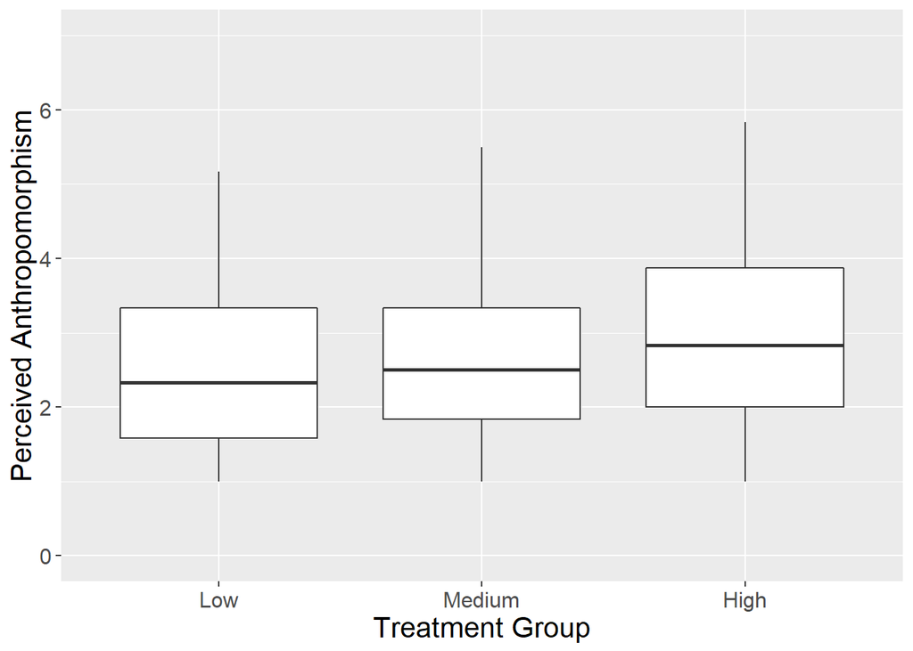

```r
a = 1.2
ggplot(dataAnalysis06, aes(x=GroupFactorRev, y=Anthropomorphism06MeasureMean)) +
  geom_boxplot(notch=FALSE,
               outlier.colour="red", outlier.shape=8, outlier.size=4) +
  labs (y = "Perceived Anthropomorphism") +
  labs (x = "Treatment Group") +
  scale_x_discrete(labels= c("Low", "Medium", "High")) +
  scale_y_continuous(limits = c(0, 7)) +
  theme(text = element_text(size=20*a), title = element_text(size=13*a),
        axis.text.x = element_text(size=10*a), axis.text.y = element_text(size=10*a),
        plot.title = element_text(size=14*a, hjust = 0.5),
        legend.text = element_text(size=10*a))
```

The boxplot graphic is then saved in a file.

```r
ggsave(filename = "R_Plots/Group_Anthro_Boxplot.png", dpi = 2000, width = 8, height = 3.64,type = "cairo")
```

### 3.3 Linear Regressions

In the following, linear regressions are calculated in order to see how different variables impact the result.

**Linear Regression 1: Social Presence as dependent variable**

```r
regression_group_sp_2 = lm(SocialPresence06MeasureMean ~ HIGH_Group_Dummy + MED_Group_Dummy + GenderFemale_Dummy + TrustInTechnologyAllMeasureMean + FinancialLiteracyFactor + EXPERT_RoboExp_Dummy + Sociability06MeasureMean + RiskBotFactor, data = dataAnalysis06)
output = tidy(regression_group_sp_2)
summary(regression_group_sp_2)
```

```
##
## Call:
## lm(formula = SocialPresence06MeasureMean ~ HIGH_Group_Dummy +
##     MED_Group_Dummy + GenderFemale_Dummy + TrustInTechnologyAllMeasureMean +
##     FinancialLiteracyFactor + EXPERT_RoboExp_Dummy + Sociability06MeasureMean +
##     RiskBotFactor, data = dataAnalysis06)
##
## Residuals:
##     Min      1Q  Median      3Q     Max
## -2.8224 -0.8950 -0.0770  0.8658  3.2972
##
## Coefficients:
##                                  Estimate Std. Error t value Pr(>|t|)
## (Intercept)                      1.834912   0.669481   2.741  0.00678 **
## HIGH_Group_Dummy                 1.180640   0.220143   5.363 2.61e-07 ***
## MED_Group_Dummy                  0.583317   0.218891   2.665  0.00843 **
## GenderFemale_Dummy               0.421261   0.184528   2.283  0.02366 *
## TrustInTechnologyAllMeasureMean  0.156509   0.066348   2.359  0.01945 *
## FinancialLiteracyFactorLOW       0.675160   0.391912   1.723  0.08673 .
## FinancialLiteracyFactorMED       0.156009   0.198900   0.784  0.43391
## EXPERT_RoboExp_Dummy            -0.092392   0.553179  -0.167  0.86755
## Sociability06MeasureMean        -0.001157   0.087891  -0.013  0.98951
## RiskBotFactorLOW                -0.124991   0.375599  -0.333  0.73971
## RiskBotFactorMED                -0.091044   0.373653  -0.244  0.80779
## ---
## Signif. codes:  0 '***' 0.001 '**' 0.01 '*' 0.05 '.' 0.1 ' ' 1
##
## Residual standard error: 1.198 on 172 degrees of freedom
## Multiple R-squared:  0.2079, Adjusted R-squared:  0.1619
## F-statistic: 4.516 on 10 and 172 DF,  p-value: 1.125e-05
```

```r
write.csv2(output, "LM_Group_SP.csv")
```

**Linear Regression 2: Social Presence as dependent variable with interaction effects**

```r
regression_group_sp_2 = lm(SocialPresence06MeasureMean ~ HIGH_Group_Dummy + MED_Group_Dummy + GenderFemale_Dummy + TrustInTechnologyAllMeasureMean + FinancialLiteracyFactor + EXPERT_RoboExp_Dummy + Sociability06MeasureMean + RiskBotFactor
                           + HIGH_Group_Dummy * GenderFemale_Dummy
                           , data = dataAnalysis06)
output = tidy(regression_group_sp_2)
summary(regression_group_sp_2)
```

```
##
## Call:
## lm(formula = SocialPresence06MeasureMean ~ HIGH_Group_Dummy +
##     MED_Group_Dummy + GenderFemale_Dummy + TrustInTechnologyAllMeasureMean +
##     FinancialLiteracyFactor + EXPERT_RoboExp_Dummy + Sociability06MeasureMean +
##     RiskBotFactor + HIGH_Group_Dummy * GenderFemale_Dummy, data = dataAnalysis06)
##
## Residuals:
##     Min      1Q  Median      3Q     Max
## -2.6622 -0.9133 -0.0980  0.9007  3.1798
##
## Coefficients:
##                                       Estimate Std. Error t value Pr(>|t|)
## (Intercept)                          1.9976246  0.6721938   2.972  0.00339
## HIGH_Group_Dummy                     0.8505819  0.2900721   2.932  0.00383
## MED_Group_Dummy                      0.5835065  0.2176258   2.681  0.00805
## GenderFemale_Dummy                   0.2127562  0.2193610   0.970  0.33347
## TrustInTechnologyAllMeasureMean      0.1482901  0.0661349   2.242  0.02623
## FinancialLiteracyFactorLOW           0.6286802  0.3905673   1.610  0.10932
## FinancialLiteracyFactorMED           0.0817295  0.2023371   0.404  0.68677
## EXPERT_RoboExp_Dummy                -0.0942703  0.5499819  -0.171  0.86411
## Sociability06MeasureMean            -0.0006299  0.0873830  -0.007  0.99426
## RiskBotFactorLOW                    -0.1206945  0.3734357  -0.323  0.74694
## RiskBotFactorMED                    -0.1010287  0.3715371  -0.272  0.78601
## HIGH_Group_Dummy:GenderFemale_Dummy  0.6686100  0.3856214   1.734  0.08475
##
## (Intercept)                         **
## HIGH_Group_Dummy                    **
## MED_Group_Dummy                     **
## GenderFemale_Dummy
## TrustInTechnologyAllMeasureMean     *
## FinancialLiteracyFactorLOW
## FinancialLiteracyFactorMED
## EXPERT_RoboExp_Dummy
## Sociability06MeasureMean
## RiskBotFactorLOW
## RiskBotFactorMED
## HIGH_Group_Dummy:GenderFemale_Dummy .
## ---
## Signif. codes:  0 '***' 0.001 '**' 0.01 '*' 0.05 '.' 0.1 ' ' 1
##
## Residual standard error: 1.191 on 171 degrees of freedom
## Multiple R-squared:  0.2216, Adjusted R-squared:  0.1716
## F-statistic: 4.426 on 11 and 171 DF,  p-value: 7.441e-06
```

```r
write.csv2(output, "LM_Group_SP_2.csv")
```

**Linear Regression 3: Social Presence as dependent variable with the effect of perceived anthropomorphism**

```r
regression_group_sp_2 = lm(SocialPresence06MeasureMean ~ HIGH_Group_Dummy + MED_Group_Dummy + GenderFemale_Dummy + TrustInTechnologyAllMeasureMean + FinancialLiteracyFactor + EXPERT_RoboExp_Dummy + Sociability06MeasureMean + RiskBotFactor
                           + Anthropomorphism06MeasureMean
                           , data = dataAnalysis06)
output = tidy(regression_group_sp_2)
summary(regression_group_sp_2)
```

```
##
## Call:
## lm(formula = SocialPresence06MeasureMean ~ HIGH_Group_Dummy +
##     MED_Group_Dummy + GenderFemale_Dummy + TrustInTechnologyAllMeasureMean +
##     FinancialLiteracyFactor + EXPERT_RoboExp_Dummy + Sociability06MeasureMean +
##     RiskBotFactor + Anthropomorphism06MeasureMean, data = dataAnalysis06)
##
## Residuals:
##      Min       1Q   Median       3Q      Max
## -2.73719 -0.68494 -0.08161  0.65908  2.35498
##
## Coefficients:
##                                 Estimate Std. Error t value Pr(>|t|)
## (Intercept)                      1.30984    0.58716   2.231   0.0270 *
## HIGH_Group_Dummy                 0.89089    0.19557   4.555 9.91e-06 ***
## MED_Group_Dummy                  0.48701    0.19103   2.549   0.0117 *
## GenderFemale_Dummy               0.14741    0.16480   0.894   0.3723
## TrustInTechnologyAllMeasureMean  0.05157    0.05945   0.867   0.3870
## FinancialLiteracyFactorLOW       0.55340    0.34164   1.620   0.1071
## FinancialLiteracyFactorMED       0.13384    0.17321   0.773   0.4408
## EXPERT_RoboExp_Dummy            -0.41758    0.48363  -0.863   0.3891
## Sociability06MeasureMean        -0.04282    0.07673  -0.558   0.5775
## RiskBotFactorLOW                -0.06898    0.32713  -0.211   0.8332
## RiskBotFactorMED                -0.08737    0.32535  -0.269   0.7886
## Anthropomorphism06MeasureMean    0.55257    0.07393   7.474 3.85e-12 ***
## ---
## Signif. codes:  0 '***' 0.001 '**' 0.01 '*' 0.05 '.' 0.1 ' ' 1
##
## Residual standard error: 1.043 on 171 degrees of freedom
## Multiple R-squared:  0.403,  Adjusted R-squared:  0.3646
## F-statistic: 10.49 on 11 and 171 DF,  p-value: 1.386e-14
```

```r
write.csv2(output, "LM_Group_SP_3.csv")
```

**A boxplot that visualized the distribution of perceived social presence between groups is created and saved to a file.**

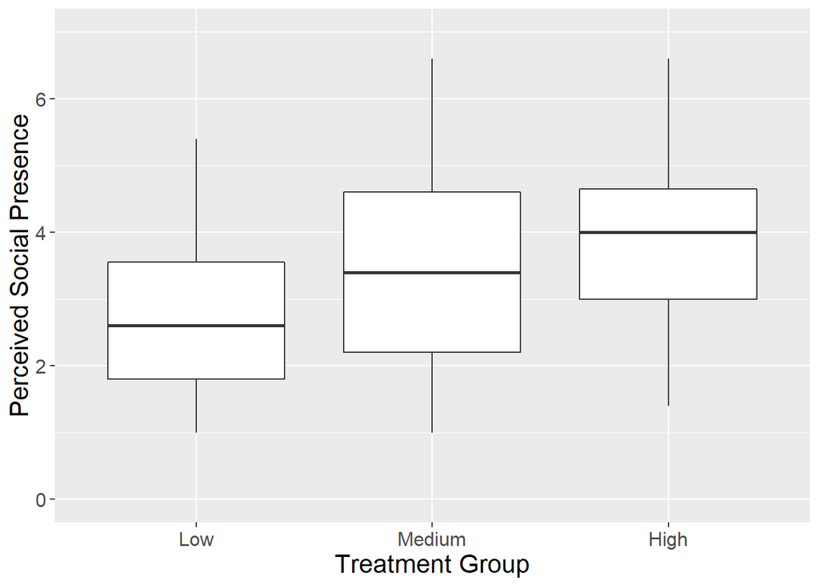

```r
ggplot(dataAnalysis06, aes(x=GroupFactorRev, y=SocialPresence06MeasureMean)) +
  geom_boxplot(notch=FALSE,
               outlier.colour="red", outlier.shape=8, outlier.size=4) +
  labs (y = "Perceived Social Presence") +
  labs (x = "Treatment Group") +
  scale_y_continuous(limits = c(0, 7)) +
  scale_x_discrete(labels= c("Low", "Medium", "High")) +
  theme(text = element_text(size=20*a), title = element_text(size=13*a),
        axis.text.x = element_text(size=10*a), axis.text.y = element_text(size=10*a),
        plot.title = element_text(size=14*a, hjust = 0.5),
        legend.text = element_text(size=10*a))
```

```r
ggsave(filename = "R_Plots/Group_SP_Boxplot.png", dpi = 2000, width = 8, height = 3.64,type = "cairo")
```

**The interaction effect between gender and treatment group on social presence is plotted and saved.**

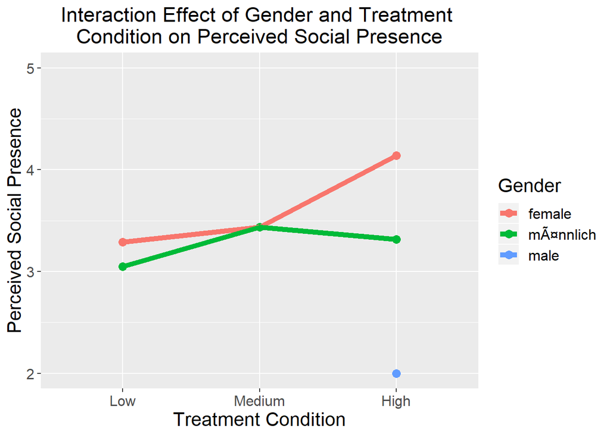

```r
a = 1.2
dataAnalysis06 %>%
  ggplot() +
  aes(x = GroupFactorRev, color = Gender, group = Gender, y = SocialPresence06MeasureMean) +
  stat_summary(fun.y = mean, geom = "point", size = 3) +
  stat_summary(fun.y = mean, geom = "line", size = 2) +
  ylim(2,5) +
  labs(x = "Treatment Condition") +
  labs (y = "Perceived Social Presence") +
  labs (title = "Interaction Effect of Gender and Treatment \nCondition on Perceived Social Presence") +
  scale_x_discrete(labels= c("Low", "Medium", "High")) +
  theme(text = element_text(size=20*a), title = element_text(size=13*a),
        axis.text.x = element_text(size=10*a), axis.text.y = element_text(size=10*a),
        plot.title = element_text(size=14*a, hjust = 0.5),
        legend.text = element_text(size=10*a))
```

```r
ggsave(filename = "R_Plots/SP_Gender_Interaction.png", dpi = 2000, width = 8, height = 3.64,type = "cairo")
```

### 3.4 Structural Equation Model

In the following, the SEM is analyzed with lavaan.

The model is set up.

```r
model <- '
  # measurement model
    SocialPresence =~ SP1 + SP3 + SP2 + SP4 + SP5
    TrustingBeliefs =~ TI_B1 + TI_B2 + TI_B3 + TI_C1 + TI_C2 + TI_C3 + TI_C4 + TI_I1 + TI_I2 + TI_I3 + TI_I4
    PerceivedUsefulness =~ PU1 + PU2 + PU3 + PU4 + PU5 + PU6
    PerceivedEnjoyment =~ PE1 + PE2 + PE3  + PE4 + PE5
    IntentionToUse =~ IU1 + IU2 + IU3 + IU4 + IU5


  # regressions
    TrustingBeliefs ~ SocialPresence
    PerceivedUsefulness ~ TrustingBeliefs + PerceivedEnjoyment
    PerceivedEnjoyment ~ SocialPresence
    IntentionToUse ~  TrustingBeliefs + PerceivedUsefulness + PerceivedEnjoyment
    Invest_Followed.y ~ SocialPresence + TrustingBeliefs

  # residual correlations

'
```

Results for the SEM are calculated.

```r
fit <- sem(model, data=dataSEM)
summary(fit, standardized=TRUE, rsquare=TRUE, fit.measures = TRUE)
```

```
## lavaan 0.6-3 ended normally after 75 iterations
##
##   Optimization method                           NLMINB
##   Number of free parameters                        107
##
##   Number of observations                           183
##
##   Estimator                                       DWLS      Robust
##   Model Fit Test Statistic                     429.235     819.544
##   Degrees of freedom                               486         486
##   P-value (Chi-square)                           0.970       0.000
##   Scaling correction factor                                  0.850
##   Shift parameter                                          314.808
##     for simple second-order correction (Mplus variant)
##
## Model test baseline model:
##
##   Minimum Function Test Statistic            10790.532    1979.521
##   Degrees of freedom                               528         528
##   P-value                                        0.000       0.000
##
## User model versus baseline model:
##
##   Comparative Fit Index (CFI)                    1.000       0.770
##   Tucker-Lewis Index (TLI)                       1.006       0.750
##
##   Robust Comparative Fit Index (CFI)                            NA
##   Robust Tucker-Lewis Index (TLI)                               NA
##
## Root Mean Square Error of Approximation:
##
##   RMSEA                                          0.000       0.061
##   90 Percent Confidence Interval          0.000  0.000       0.054  0.069
##   P-value RMSEA <= 0.05                          1.000       0.006
##
##   Robust RMSEA                                                  NA
##   90 Percent Confidence Interval                                NA     NA
##
## Standardized Root Mean Square Residual:
##
```

[output cut: 237 more lines]

```
##     PE1               0.397
##     PE2               0.333
##     PE3               0.450
##     PE4               0.525
##     PE5               0.668
##     IU1               0.668
##     IU2               0.747
##     IU3               0.397
##     IU4               0.641
##     IU5               0.669
##     Invest_Fllwd.y    0.170
##     TrustingBelifs    0.271
##     PercevdUsflnss    0.565
##     PercevdEnjymnt    0.769
##     IntentionToUse    0.738
```

```r
inspect(fit,"r2")
```

```
##                 SP1                 SP3                 SP2
##               0.503               0.355               0.094
##                 SP4                 SP5               TI_B1
##               0.254               0.299               0.569
##               TI_B2               TI_B3               TI_C1
##               0.455               0.347               0.554
##               TI_C2               TI_C3               TI_C4
##               0.747               0.575               0.427
##               TI_I1               TI_I2               TI_I3
##               0.491               0.509               0.295
##               TI_I4                 PU1                 PU2
##               0.406               0.531               0.590
##                 PU3                 PU4                 PU5
##               0.767               0.685               0.643
##                 PU6                 PE1                 PE2
##               0.596               0.397               0.333
##                 PE3                 PE4                 PE5
##               0.450               0.525               0.668
##                 IU1                 IU2                 IU3
##               0.668               0.747               0.397
##                 IU4                 IU5   Invest_Followed.y
##               0.641               0.669               0.170
##     TrustingBeliefs PerceivedUsefulness  PerceivedEnjoyment
##               0.271               0.565               0.769
##      IntentionToUse
##               0.738
```

SEM path model is visualized.

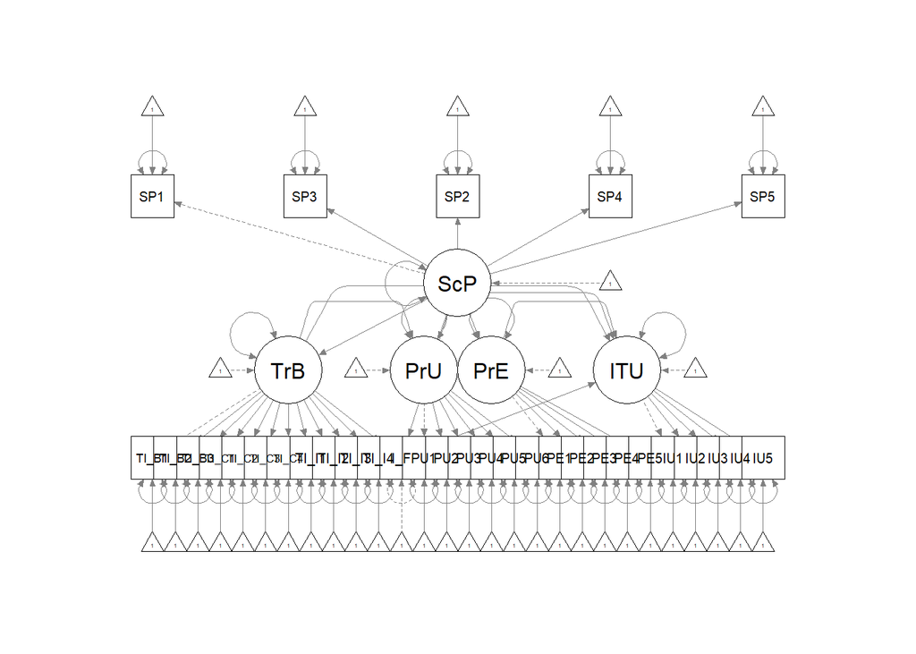

```r
semPaths(fit, title = FALSE, curvePivot = TRUE)
```

### 3.5 Other Analyses

In the following, further analyses that are described in the master’s thesis are calculated.

```r
regression_group_sp_2 = lm(TrustAll06MeasureMean ~ HIGH_Group_Dummy + MED_Group_Dummy + GenderFemale_Dummy + TrustInTechnologyAllMeasureMean + SocialPresence06MeasureMean
                           , data = dataAnalysis06)
summary(regression_group_sp_2)
```

```
##
## Call:
## lm(formula = TrustAll06MeasureMean ~ HIGH_Group_Dummy + MED_Group_Dummy +
##     GenderFemale_Dummy + TrustInTechnologyAllMeasureMean + SocialPresence06MeasureMean,
##     data = dataAnalysis06)
##
## Residuals:
##     Min      1Q  Median      3Q     Max
## -3.4172 -0.6969  0.0285  0.6934  1.9878
##
## Coefficients:
##                                 Estimate Std. Error t value Pr(>|t|)
## (Intercept)                      3.46200    0.29651  11.676  < 2e-16 ***
## HIGH_Group_Dummy                -0.10543    0.18523  -0.569  0.56994
## MED_Group_Dummy                  0.15077    0.17374   0.868  0.38668
## GenderFemale_Dummy               0.32949    0.14346   2.297  0.02280 *
## TrustInTechnologyAllMeasureMean  0.12690    0.05257   2.414  0.01681 *
## SocialPresence06MeasureMean      0.22796    0.05933   3.842  0.00017 ***
## ---
## Signif. codes:  0 '***' 0.001 '**' 0.01 '*' 0.05 '.' 0.1 ' ' 1
##
## Residual standard error: 0.9415 on 177 degrees of freedom
## Multiple R-squared:  0.1687, Adjusted R-squared:  0.1452
## F-statistic: 7.184 on 5 and 177 DF,  p-value: 3.805e-06
```

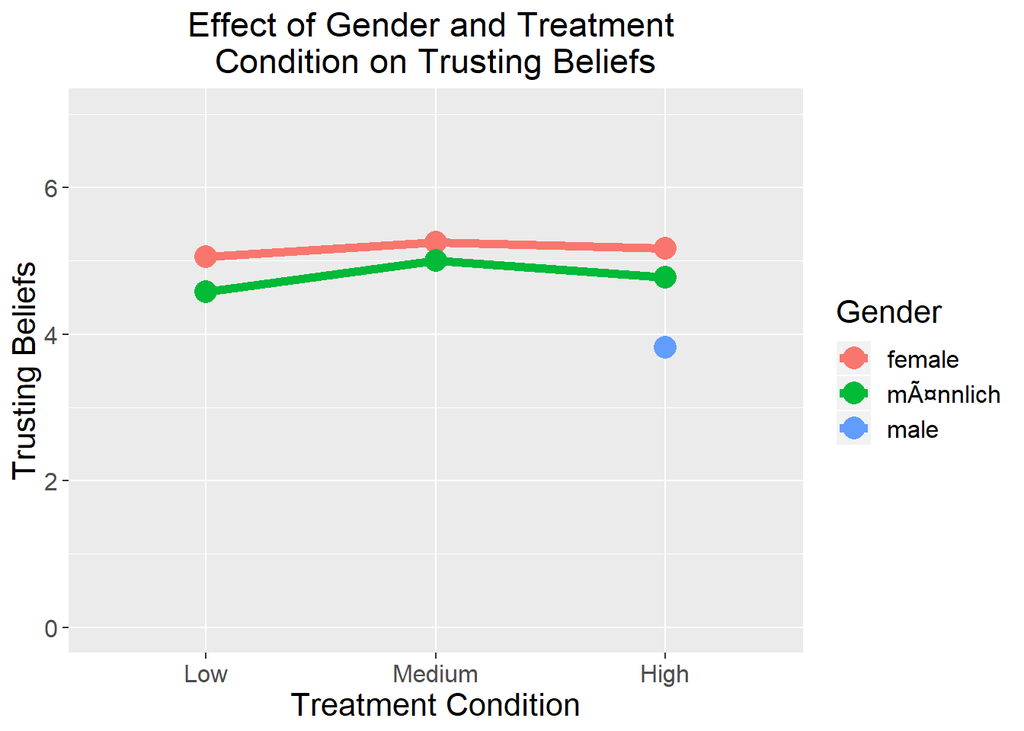

```r
dataAnalysis06 %>%
  ggplot() +
  aes(x = GroupFactorRev, color = Gender, group = Gender, y = TrustAll06MeasureMean) +
  stat_summary(fun.y = mean, geom = "point", size = 5) +
  stat_summary(fun.y = mean, geom = "line", size = 2) +
  ylim(0,7) +
  labs(x = "Treatment Condition") +
  labs (y = "Trusting Beliefs") +
  labs (title = "Effect of Gender and Treatment \nCondition on Trusting Beliefs") +
  scale_x_discrete(labels= c("Low", "Medium", "High")) +
  theme(text = element_text(size=20*a), title = element_text(size=13*a),
        axis.text.x = element_text(size=10*a), axis.text.y = element_text(size=10*a),
        plot.title = element_text(size=14*a, hjust = 0.5),
        legend.text = element_text(size=10*a))
```

**Linear Regression 5: Effect of win or loss on NPS moderated by users’ choice to follow or not**

```r
regression_group_sp_2 = lm(NPS ~ HIGH_Group_Dummy + MED_Group_Dummy
                           + IntentionToUse06MeasureMean
                           + ProfitMade + Invest_Followed + ProfitMade * Invest_Followed
                           + GenderFemale_Dummy + TrustInTechnologyAllMeasureMean + EXPERT_RoboExp_Dummy + Sociability06MeasureMean + RiskBotFactor
                           , data = dataAnalysis06)
summary(regression_group_sp_2)
```

```
##
## Call:
## lm(formula = NPS ~ HIGH_Group_Dummy + MED_Group_Dummy + IntentionToUse06MeasureMean +
##     ProfitMade + Invest_Followed + ProfitMade * Invest_Followed +
##     GenderFemale_Dummy + TrustInTechnologyAllMeasureMean + EXPERT_RoboExp_Dummy +
##     Sociability06MeasureMean + RiskBotFactor, data = dataAnalysis06)
##
## Residuals:
##     Min      1Q  Median      3Q     Max
## -4.8827 -1.3276  0.0291  1.2788  4.5446
##
## Coefficients:
##                                    Estimate Std. Error t value Pr(>|t|)
## (Intercept)                         0.18259    1.16777   0.156   0.8759
## HIGH_Group_Dummy                   -0.49969    0.34581  -1.445   0.1503
## MED_Group_Dummy                    -0.53585    0.34505  -1.553   0.1223
## IntentionToUse06MeasureMean         1.01776    0.12394   8.212 5.25e-14
## ProfitMadeTRUE                     -0.64867    0.70361  -0.922   0.3579
## Invest_FollowedTRUE                -2.25450    0.51533  -4.375 2.11e-05
## GenderFemale_Dummy                  0.75017    0.29178   2.571   0.0110
## TrustInTechnologyAllMeasureMean     0.12141    0.11119   1.092   0.2764
## EXPERT_RoboExp_Dummy                1.86745    0.88324   2.114   0.0359
## Sociability06MeasureMean            0.05629    0.13743   0.410   0.6826
## RiskBotFactorLOW                   -0.55843    0.59720  -0.935   0.3511
## RiskBotFactorMED                   -0.24787    0.59225  -0.419   0.6761
## ProfitMadeTRUE:Invest_FollowedTRUE  4.02656    0.77096   5.223 5.10e-07
##
## (Intercept)
## HIGH_Group_Dummy
## MED_Group_Dummy
## IntentionToUse06MeasureMean        ***
## ProfitMadeTRUE
## Invest_FollowedTRUE                ***
## GenderFemale_Dummy                 *
## TrustInTechnologyAllMeasureMean
## EXPERT_RoboExp_Dummy               *
## Sociability06MeasureMean
## RiskBotFactorLOW
## RiskBotFactorMED
## ProfitMadeTRUE:Invest_FollowedTRUE ***
## ---
## Signif. codes:  0 '***' 0.001 '**' 0.01 '*' 0.05 '.' 0.1 ' ' 1
##
## Residual standard error: 1.884 on 170 degrees of freedom
## Multiple R-squared:  0.5172, Adjusted R-squared:  0.4831
## F-statistic: 15.18 on 12 and 170 DF,  p-value: < 2.2e-16
```

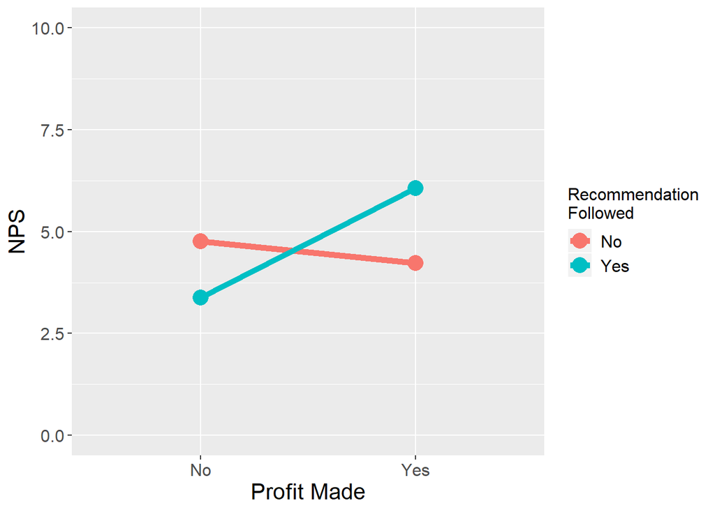

```r
output = tidy(regression_group_sp_2)
write.csv2(output, "R_Models/NPS.csv")

dataAnalysis06 %>%
  ggplot() +
  aes(x = ProfitMade, color = Invest_Followed, group = Invest_Followed, y = NPS) +
  stat_summary(fun.y = mean, geom = "point", size = 5) +
  stat_summary(fun.y = mean, geom = "line", size = 2) +
  ylim(0,10) +
  labs(x = "Profit Made") +
  labs (y = "NPS") +
  #labs (title = "Effect of Gender and Treatment \nCondition on Trusting Beliefs") +
  scale_x_discrete(labels= c("No", "Yes")) +
  scale_color_discrete(name = "Recommendation\nFollowed", labels = c("No", "Yes")) +
  theme(text = element_text(size=20*a), title = element_text(size=13*a),
        axis.text.x = element_text(size=10*a), axis.text.y = element_text(size=10*a),
        plot.title = element_text(size=14*a, hjust = 0.5),
        legend.text = element_text(size=10*a),
        legend.title = element_text(size=10*a))
```

**Linear Regression 6: Effect of win or loss on user satisfaction moderated by users’ choice to follow or not**

```r
regression_group_sp_2 = lm(SatisfactionAllMeasureMean ~ HIGH_Group_Dummy + MED_Group_Dummy
                           + IntentionToUse06MeasureMean
                           + ProfitMade + Invest_Followed + ProfitMade * Invest_Followed
                           + GenderFemale_Dummy + TrustInTechnologyAllMeasureMean + EXPERT_RoboExp_Dummy + Sociability06MeasureMean + RiskBotFactor
                           , data = dataAnalysis06)
summary(regression_group_sp_2)
```

```
##
## Call:
## lm(formula = SatisfactionAllMeasureMean ~ HIGH_Group_Dummy +
##     MED_Group_Dummy + IntentionToUse06MeasureMean + ProfitMade +
##     Invest_Followed + ProfitMade * Invest_Followed + GenderFemale_Dummy +
##     TrustInTechnologyAllMeasureMean + EXPERT_RoboExp_Dummy +
##     Sociability06MeasureMean + RiskBotFactor, data = dataAnalysis06)
##
## Residuals:
##      Min       1Q   Median       3Q      Max
## -2.99019 -0.51340  0.09726  0.57070  2.12173
##
## Coefficients:
##                                    Estimate Std. Error t value Pr(>|t|)
## (Intercept)                         3.20064    0.56570   5.658 6.38e-08
## HIGH_Group_Dummy                   -0.12774    0.16752  -0.763 0.446801
## MED_Group_Dummy                     0.07547    0.16715   0.452 0.652197
## IntentionToUse06MeasureMean         0.32746    0.06004   5.454 1.71e-07
## ProfitMadeTRUE                     -0.12934    0.34085  -0.379 0.704818
## Invest_FollowedTRUE                -0.97526    0.24964  -3.907 0.000135
## GenderFemale_Dummy                  0.43669    0.14135   3.089 0.002343
## TrustInTechnologyAllMeasureMean     0.13185    0.05386   2.448 0.015388
## EXPERT_RoboExp_Dummy                0.60572    0.42787   1.416 0.158705
## Sociability06MeasureMean           -0.03220    0.06658  -0.484 0.629266
## RiskBotFactorLOW                   -0.43732    0.28930  -1.512 0.132484
## RiskBotFactorMED                   -0.45645    0.28690  -1.591 0.113481
## ProfitMadeTRUE:Invest_FollowedTRUE  1.74041    0.37348   4.660 6.36e-06
##
## (Intercept)                        ***
## HIGH_Group_Dummy
## MED_Group_Dummy
## IntentionToUse06MeasureMean        ***
## ProfitMadeTRUE
## Invest_FollowedTRUE                ***
## GenderFemale_Dummy                 **
## TrustInTechnologyAllMeasureMean    *
## EXPERT_RoboExp_Dummy
## Sociability06MeasureMean
## RiskBotFactorLOW
## RiskBotFactorMED
## ProfitMadeTRUE:Invest_FollowedTRUE ***
## ---
## Signif. codes:  0 '***' 0.001 '**' 0.01 '*' 0.05 '.' 0.1 ' ' 1
##
## Residual standard error: 0.9128 on 170 degrees of freedom
## Multiple R-squared:  0.4785, Adjusted R-squared:  0.4416
## F-statistic:    13 on 12 and 170 DF,  p-value: < 2.2e-16
```

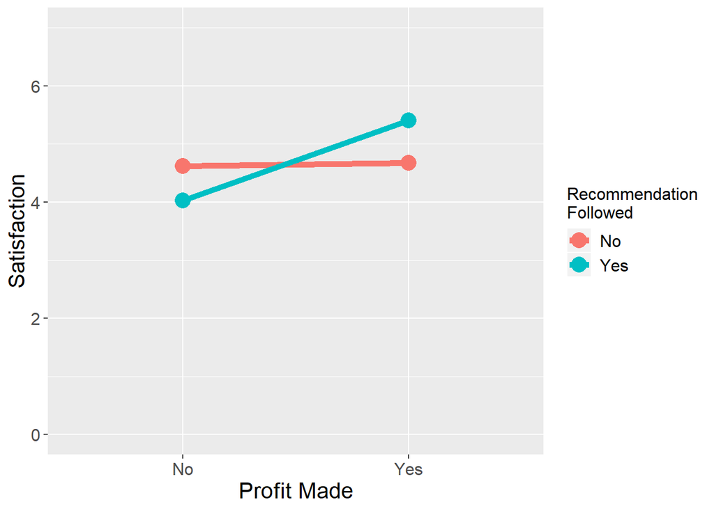

```r
output = tidy(regression_group_sp_2)
write.csv2(output, "R_Models/Satisfaction.csv")

dataAnalysis06 %>%
  ggplot() +
  aes(x = ProfitMade, color = Invest_Followed, group = Invest_Followed, y = SatisfactionAllMeasureMean) +
  stat_summary(fun.y = mean, geom = "point", size = 5) +
  stat_summary(fun.y = mean, geom = "line", size = 2) +
  ylim(0,7) +
  labs(x = "Profit Made") +
  labs (y = "Satisfaction") +
  #labs (title = "Effect of Gender and Treatment \nCondition on Trusting Beliefs") +
  scale_x_discrete(labels= c("No", "Yes")) +
  scale_color_discrete(name = "Recommendation\nFollowed", labels = c("No", "Yes")) +
  theme(text = element_text(size=20*a), title = element_text(size=13*a),
        axis.text.x = element_text(size=10*a), axis.text.y = element_text(size=10*a),
        plot.title = element_text(size=14*a, hjust = 0.5),
        legend.text = element_text(size=10*a),
        legend.title = element_text(size=10*a))
```